# Introducción a la estadística Bayesiana

Rosana Zenil-Ferguson

2024-12-29

# ¿Qué es la estadística Bayesiana?

La estadística bayesiana es una rama del estudio de la Estadística que se enfoca en la inferencia y pronóstico de la probabilidades de eventos inciertos. El objetivo más importante de la estadística bayesiana es siempre proporcionar una medida de la incertidumbre y no solamente un estimador. Esta idea la discutiremos una y otra vez a través de los ejercicios del taller.

Existen dos diferencias centrales de la estadística Bayesiana cuando la comparamos con la forma de hacer estadística tradicional (ya sea frecuentista o bajo el método de verosimilitud). Estas diferencias son las siguientes:

1. Cómo se miden las probabilidades en Bayesiana es distinto a cómo se define la probabilidad en estadística tradicional.
2. Los parámetros en estadística Bayesiana son desconocidos pero también son **variables aleatorias**. En estadística tradicional, los parámetros son desconocidos pero son variables fijas. Esta diferencia es esencial.

## ¿Por qué los frecuentistas y Bayesianos pelean?

Desde el punto de vista práctico, estas discusiones son filosóficas. Generalmente, en biología estas discusiones ni siquiera son filosóficas, sino una serie de malos entendidos. En el campo de la estadística, los frecuentistas tienen una larga historia de discusiones que empezaron a principios del siglo XX, con la introducción de un concepto que estudiaremos hoy: La función de la verosimilitud. Es interesante ver que hasta el día de hoy la gente confunde estadística frecuentista con la verosimilitud a pesar de que la verosimilitud y la estadística Bayesiana van de la mano.

## ¿Cuándo hacemos estadística bayesiana y cuando no?

En Biología, escogemos hacer inferencia bayesiana porque es una herramienta computacional poderosa. En particular, la estadística bayesiana utiliza el algoritmo MCMC (Monte Carlo Markov Chain), descubierto a mediados de 1970. Este algoritmo es super util, y en su forma más basica es sencillo de implementar, o esta presente en casi cualquier software bayesiano. Utilizar e implementar MCMCs es un arte, toma tiempo y esfuerzo, pero vale la pena por la calidad de la inferencia. Cualquier inferencia estadística pero especialmente la estadística bayesiana debe ser tratada como un experimento de laboratorio toma tiempo, dinero y esfuerzo en hacerse de manera correcta.

## Conceptos bayesianos importantes

La estadística bayesiana deriva su nombre del Teorema de Bayes del estudio de la probabilidad. Dados dos eventos $A$ and $B$, la probabilidad condicional de $A$ **dado** $B$ se define como

$$P(A|B)=\frac{P(AB)}{P(B)}$$
y aplicando dos veces el teorema de Bayes obtenemos que

$$P(A|B)=\frac{P(B|A)P(A)}{P(B)}$$

## Ejemplo: El experimento de un reality show “El amor es ciego”

Las citas en línea o a ciegas son difíciles, especialmente si tu personalidad es reservada. Estas citas son especialmente difíciles para los estadísticos bayesianos porque entienden sus probabilidades muy bien. Imaginemos por un momento que vamos a ver un reality show que se llama “El amor es ciego”, como estadísticos bayesianos vamos es estimar la probabilidad de que uno de los participantes se enamore y se case. El experimento consiste en poner a una persona, llamada Silvia, en una serie de citas a ciegas hasta que encuentre al amor de su vida y se case. Para lograrlo Silvia debe tener un indice alto de carisma. Como estadísticos, vamos a estimar la probabilidad de que una persona tenga gran carisma.

### Definición de eventos

Defininamos dos eventos a los que les vamos a medir la probabilidad

1. $A$ = Es el evento que representa que Silvia es muy carismática
2. $B$ = Es el evento que representa cuantas de las citas a ciegas de Silvia salieron bien.

### Definición de probabilidad a priori

Con estos dos eventos se puede caracterizar este reality show. Como expectadores y estadísticos nosotros podemos definir de entrada algunas probabilidades. Por ejemplo, en el primer capítulo, se hace la introducción de Silvia y de entrada no sabemos mucho de Silvia. Dos decisiones que podemos tomar

1.$P(A)=0.5$ representa la probabilidad de que Silva es carismática o no con la misma probabilidad

2. $P(A)=0.1$ porque Silvia dijo en su introducción “no me gustan los perros” y entonces decidimos que Silvia tiene una probabilidad bajita de ser carismática

Estos ejemplos de decisiones sin antes de ver el resultado de ninguna de las citas se llama **probabilidad *a priori*.** La probabilidad a priori es un paso necesario de la estadística bayesiana que refleja nuestras creencias y es subjetiva, puede ser informativa (conoces a Silvia y sabes que es buena persona), o no informativa (50-50 a que Silvia es buena persona).

### El objetivo final: $P(A|B)$

En realidad lo que nos interesa como estadísticos bayesianos es saber el resultado final para Silvia ¿acabará enamorandose?, en términos de probabilidad nos interesa lo que llamamos la probabilidad a posteriori, es decir $P(A|B)$ = la probabilidad del carisma de Silvia dadas las citas exitosas durante el reality show. En algunos contextos la probabilidad a posteriori se le conoce como la actualización de las probabilidades porque conocemos más del carisma de Silvia cada vez que tiene una cita en el reality.

### $P(A|B)$ es difícil de estimar

¿Cómo obtenemos esta probabilidad posterior? Si lo pensamos bien $P(A|B)$ es una probabilidad difícil, ¿cómo cambia el carisma de Silvia después de las citas exitosas? es algo raro de describir, pero es lo que queremos saber, entonces ¿cómo empezamos a calcular esta probabilidad posterior?

Lo más sencillo es pensar el probabilidad siguiente:

$P(B|A)$: Dado que conocemos el carisma de Silvia, la probabilidad de la cita es…

Esta segunda probabilidad condicional $P(B|A)$ es muchísimo más sencilla de entender y de pensar. Afortunadamente el teorema de Bayes liga esta probabilidad más sencilla a la más difícil

$$P(A|B)=\frac{P(B|A)P(A)}{P(B)}$$

## Conceptos bayesianos (parte 2)

1. La estadística bayesiana define las probabilidades a través de un proceso de apuestas. No hay forma clara de decidir una propbabilidad a priori para el carima de Silvia $P(A)$. Recuerda que las distribución a priori es subjetiva y por esta razón queremos tener mucho cuidado al decidir. El proceso de decisión se llama en estadística bayesiana **elicitar** y no debe usar nada de la información de las citas.

Hagamos entonces el proceso de elicitar la a priori del carisma de Silvia a través de una variable aletoria

### Elicitación de la distribución a priori

Para definir una probabilidad de manera correcta necesitamos aprender un concepto nuevo **variables aleatorias**. Las variables aleatorias son una **función matemática** que nos lleva del espacio de eventos al espacio de los números.

$A$: El carísma de Silvia.

$X$: variable aleatoria (una función) que se define como

$$X= \begin{cases}
0 & \textrm{cuando } A^C \textrm{ Silvia no tiene carisma}\\
1 & \textrm{cuando } A \textrm{ Silvia tiene carisma}
\end{cases}$$

En lugar de utilizar $P(A)$ utilizamos $P(X=1)$ y las dos cosas significan lo mismo.

Ahora asumimos que $P(X=1)$ es un valor llamado $\theta$ entre 0 and 1, esto también significa que $P(X=0)=1-\theta$. Si Silvia no es carismática escogimos $\theta=0.1$ y puede ser que esto esté bien, pero en el mundo real el carísma de una persona fluctua dependiendo de muchos factores. Entonces una mejor aproximación para medir el carisma de Silvia es asumir que $\theta$ (parameter) es incierto y lo vamos a modelar.

Para modelar este parametro vamos a utilizar una distribución de probabilidad llamada **Beta** (busca en Wikipedia la distribución Beta).Esta distribución de probabilidad es conveniente porque toma valores en el intervalo (0, 1) y tiene muchas formas. Exploremos como se ve una distribución beta

```r
theta <- .1 # Silvia no es carismática
# Beta tiene dos parametros a y b. La media de una distribución beta es a/(a+b)


prior_distribution<-function(theta, a, b){
beta_val<-dbeta(theta, a, b)
return(beta_val)}# Por qué es más grande que uno?

a     <- 2
b     <- 5
prior_distribution (0.1, a, b)
```

```
## [1] 1.9683
```

```r
# Tidyverse es un paquete que crea y oraniza "tibbles" tablas con un formato más sencillo de organizar

# install.packages(tidyverse) #Instala estos paquetes si no los tienes

# ggplot2 paquete para visualizar las figuras

# install.packages(ggplot2) # Instala estos paquetes si no los tienes.
# install.packages(dplyr) # Instala estos paquetes si no los tienes.

library(tidyverse,quietly=TRUE)
library(ggplot2,quietly=TRUE)
library(dplyr,quietly=TRUE)

length <- 1e4

# Creando una tabla de valores a y b para que podamos ver las diferentes formas que crea la distribución Beta

d <-
  crossing(shape1 = c(.1, 1:4),
           shape2 = c(.1, 1:4)) %>%
  expand(nesting(shape1, shape2),
         x = seq(from = 0, to = 1, length.out = length)) %>%
  mutate(a     = str_c("a =", shape1),
         b     = str_c("b =", shape2),
         group = rep(1:length, each = 25))

head(d) #you can see what is in the table
```

```
## # A tibble: 6 × 6
##   shape1 shape2        x a      b      group
##    <dbl>  <dbl>    <dbl> <chr>  <chr>  <int>
## 1    0.1    0.1 0        a =0.1 b =0.1     1
## 2    0.1    0.1 0.000100 a =0.1 b =0.1     1
## 3    0.1    0.1 0.000200 a =0.1 b =0.1     1
## 4    0.1    0.1 0.000300 a =0.1 b =0.1     1
## 5    0.1    0.1 0.000400 a =0.1 b =0.1     1
## 6    0.1    0.1 0.000500 a =0.1 b =0.1     1
```

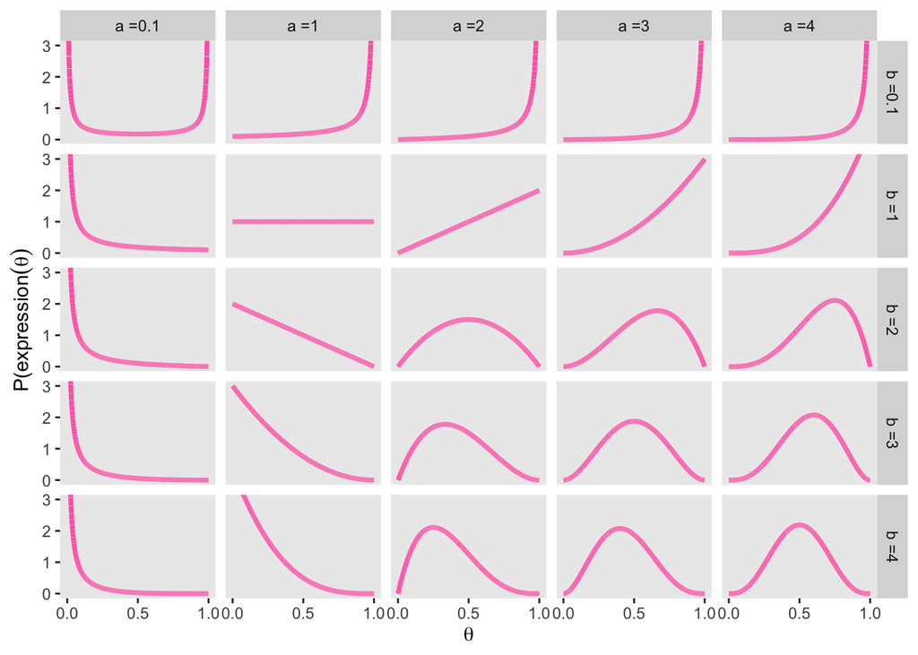

```r
# Graficando las distribuciones beta
d %>%
  ggplot(aes(x = x, group = group)) +

  geom_line(aes(y = dbeta(x, shape1 = shape1, shape2 = shape2)),
            color = "hotpink", size = 1.25) +
  scale_x_continuous(breaks = c(0, .5, 1)) +coord_cartesian(ylim = c(0,3))+
  labs(x = expression(theta),
       y = expression(paste("P(",expression(theta)))) +
  theme(panel.grid = element_blank()) +
  facet_grid(b~a)
```

Pasemos un momento interpretando las distribuciones beta. Estas son distribuciones a priori potenciales sujetas a nuestras creencias sobre el carisma de Silvia.

Con estas distribuciones mostramos el segundo punto esencial de la estadística bayesiana:

**2. Los parametros son desconocidos pero inciertos, necesitan una distribución de probabilidad.**

Logramos esto a través de $\theta$ con la **distribución a priori** $Beta(a,b)$.

## Los datos, las citas a ciegas

En el reality show, Silvia tiene tres citas completamente a ciegas con la misma persona (ninguno se ve solo se escuchan el uno al otro). En nuestros términos estadísticos $N=3$ es el número total de citas con la misma persona. ¿Cómo modelamos los resultados de estas tres citas, sabiendo el carisma de Silvia? Si recordamos el evento $B$ es el número de citas que fueron bien, pero necesitamos llevar el evento B al espacio de los números reales.

Proponemos la varialbe aleatoria $Y$ donde

$$Y=0,1,2,3 \textrm{ son el número de
citas que salieron bien}$$
La probabilidad del número de citas que salieron bien va a ser dependiente del carisma de Silvia, recordemos que ese carisma se mide a través de $\theta$. Vamos a proponer una nueva distribución para el resultado de las citas

$$P(Y=k|\theta)= {N\choose k} \theta^k
(1-\theta)^{N-k}$$
Exploremos esta distribución de probabilidad

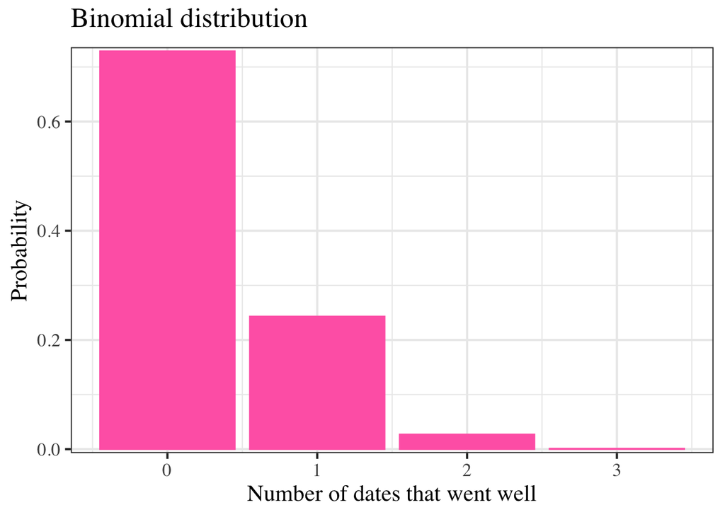

```r
# install.packages(grid) # Installa esto si no lo tienes.
library(grid)

date_number  <- 0:3
theta<-0.1
df <- data.frame(x = date_number, y = dbinom(date_number, 3, 0.1))

p1 <- ggplot(df, aes(x = x, y = y)) +
  geom_bar(stat = "identity", col = "hotpink", fill = "hotpink") +
  scale_y_continuous(expand = c(0.01, 0)) + xlab("x") + ylab("Density") +
  labs(title = "dbinom(x, 20, 0.5)") + theme_bw(16, "serif") +
  theme(plot.title = element_text(size = rel(1.2), vjust = 1.5))+
  labs(title="Binomial distribution", x ="Number of dates that went well", y = "Probability")

p1
```

Hay una segunda persona en el show para Silvia. Por el momento pensemos que con la primera persona dos de las tres citas salieron bien. La probabilidad de que dos citas salieron bien dado que sabemos el carisma de Silvia es

$$P(Y=2|\theta)= {3\choose 2} \theta^2
(1-\theta)^1$$
Si $\theta=0.1$ entonces $P(Y=2|\theta=0.1)= {3\choose 2} 0.1^2 (0.9)^1=0.027$. Quiere decir que si Silvia no es carismática entonces la probabilidad de tener dos citas buenas es 2.7%. Este es un escenario **inverosímil**. Esta es la palabra correcta en este contexto, vamos a empezar a introducir el concepto de la **función de verosimilitud**.

Lo que acabamos de hacer es observar un resultado de la distribución binomial $y_1=2$ y cuando Silvia salga con la segunda persona vamos a observar que $y_2=1$ y así hasta que Silvia haya salido con todos los candidatos.

### La función de verosimilitud (likelihood function)

$$P(Y=y_1|\theta)\times P(Y=y_2|\theta) =
{3\choose 2} \theta^2 (1-\theta)^{1}\times {3\choose 1} \theta^1
(1-\theta)^{2} \approx
\theta^{2+1}(1-\theta)^{1+2}=\theta^3(1-\theta)^3$$
**La función de verosimilitud** se define como la probabilidad de los datos dado el modelo. El modelo en este caso es $\theta$, el carisma de Silvia. La probabilidad de los datos es la multiplicación de los resultados de las citas con cada persona, es una multiplicación porque lo que pase con una persona es independiente de lo que pase con la otra.

$$P(Datos|\theta)=
\prod_{y_i=1}^{2}P(Y=y_i|\theta)\approx \theta^3(1-\theta)^3$$
Si no tenemos información a priori sobre $\theta$, ¿qué diriamos sobre el carisma de Silvia si ya observamos 2 de 3 con la primera persona, y 1 de 3 con la segunda?

```r
binomial_likelihood <- function(theta, data,n) {

# `theta` = Probabilidad de que Silvia sea carismática
# `data`  = Datos como resultaron las citas de Silvia
  long<-length(theta)
  z<-rep(0,long)
  for(i in 1:long){
  prob.vect<-sapply(data,FUN=dbinom, size=n, prob=theta[i])
  z[i]<- prod(prob.vect)
  }
  return(z)
}

observed_dates<- c(2,1)
binomial_likelihood(theta=c(0.1,0.3), data=observed_dates,n=3)
```

```
## [1] 0.006561 0.083349
```

La verosimilitud es muchas veces criticada o confundida como frecuentista. Esto es incorrecto, la verosimilitud es una función extremadamente útil, que conecta los datos con el modelo y se interpreta como la evidencia que los datos tienen sobre el modelo.

## Inferencia bayesiana: La distribución posterior

Finalmente vamos a calcular $P(A|B)$ o en el nuevo lenguaje de nuestras variables aleatorias $P(\theta|Datos)$ es la distribución posterior del carisma de Silvia

La distribución posterior es **proporcional** a la verosimilitud multiplicada por la distribución a priori
$$\underbrace{P(\theta|Data)}_{Posterior}\propto
\underbrace{P(Data|\theta)}_{Likelihood}\times
\underbrace{P(\theta)}_{Prior}$$
La parte proporcional viene de ignoral el denominador del teorema de Bayes porque no contiene nada de información sobre $\theta$.

$$P(\theta|Datos)\propto
\underbrace{\theta^k(1-\theta)^{n-k}}_{\textrm{Verosimilitud (producto
de las binomiales)}} \times
\underbrace{\theta^{a-1}(1-\theta)^{b-1}}_{\textrm{prior Beta
distribution}}$$
Esto se ve feo en ecuación, pero veamos las gráficas.

```r
# En este gráfico vamos a comparar la a priori, la verosimilitud, y la posterior.
trial_data <- c(1,2)
number_dates<-3
a<-2
b<-5

d <-
  tibble(theta0 = seq(from = 0, to = 1, length.out = 100)) %>%
  mutate(`Prior (beta)`           = dbeta(theta0,
                                          shape1 = a,
                                          shape2 = b),
         `Likelihood (Binomial)` = binomial_likelihood(theta = theta0,                                                      data=trial_data,n=number_dates),
         `Posterior (beta)`       = dbeta(theta0,
                                          shape1 = 4,
                                          shape2 = 7))

glimpse(d)
```

```
## Rows: 100
## Columns: 4
## $ theta0                  <dbl> 0.00000000, 0.01010101, 0.02020202, 0.03030303…
## $ `Prior (beta)`          <dbl> 0.0000000, 0.2909709, 0.5585502, 0.8038064, 1.…
## $ `Likelihood (Binomial)` <dbl> 0.000000e+00, 8.997245e-06, 6.979696e-05, 2.28…
## $ `Posterior (beta)`      <dbl> 0.0000000000, 0.0008145523, 0.0061274945, 0.01…
```

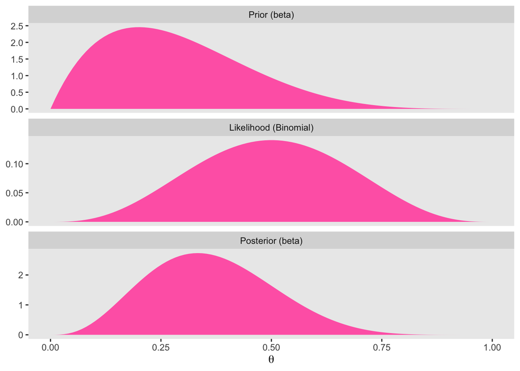

```r
d %>%
  gather(key, value, -theta0) %>%
  mutate(key = factor(key, levels = c("Prior (beta)", "Likelihood (Binomial)", "Posterior (beta)"))) %>%

  ggplot(aes(x = theta0)) +
  # densities
  geom_ribbon(aes(ymin = 0, ymax = value),
              fill = "hotpink") +
  labs(x = expression(theta),
       y = NULL) +
  facet_wrap(~key, scales = "free_y", ncol = 1) +
  theme(panel.grid = element_blank())
```

Perfecto, pero ¿cómo calculo la posterior?

## Inferencia Bayesiana utilizando el algoritmo MCMC

El algoritmo MCMC (Markov Chain Monte Carlo) nos permite optimizar la distribución posterior. En este tutorial vamos a hacer un tipo de MCMC llamado Metropolis-Hastings que es un algoritmo de rechazo. El algoritmo va a proponer un valor para el carisma de Silvia $\theta$ y se pregunta: el valor que propuse ¿incrementa el valor de la probabilidad posterior?- si la respuesta es positiva, nos quedamos este valor, y si es negativa lo rechazamos.

Manos a la obra

### La propuesta

Vamos a proponer un nuevo parámetro $\theta_{new}$ utilizando una distribución uniforme entre 0 y uno

```r
proposalfunction <- function(nvals=1){
  unif_val<-runif(nvals,min=0, max=1)
  return(unif_val)}
# Esta es una propuesta de una distribución uniforme. Selecciona valores aleatorios entre 0 y 1
```

### El algoritmo de Metropolis-Hastings

En resúmen el algoritmo de Metropolis-Hastings sigue los siguientes pasos:

1. Empieza con un valor para $\theta$ (`startvalue`) llamado $\theta_0$
2. Haz $\theta_{old}=\theta_0$
3. Calcula la distribución posterior $P(\theta_{old}|Datos)$
4. Proponer una distribución aleatoria $g(\theta)$ para obtener un nuevo valor $\theta_new$
5. Calcula la distribución posterior $P(\theta_{new}|Datos)$
6. Calcula los momios $momios=\frac{P(\theta_{new}|Datos)}{P(\theta_{old}|Datos)}$
7. Calcula un valor aleatorio $u$ entre 0 y 1
8. Si $u< momios$ entonces acepta $\theta_{new}$, guárdalo, sino rechaza y no lo guardes.
9. Si lo aceptas haz $\theta_{old}=\theta_{new}$ y vuelve al paso dos hasta acabar las iteraciones. Sino continua al paso dos con el mismo $\theta_{old}$ hasta acabar las iteraciones.

Vamos a seleccionar un valor para $\theta$ de entrada que lo llamamos `startvalue` y el número de veces que vamos a buscar se llama `iterations`. El número de iteraciones va a depender de un criterio de convergencia en los pasos 5-7.

```r
a<-2
b<-5

run_metropolis_MCMC <- function(startvalue, iterations){
    chain = rep (0,iterations+1)
    # Empezamos un un startvalue
    chain[1] = startvalue
    for (i in 1:iterations){
        theta_old<-chain[i]
# Llamamos a la propuesta, por favor danos un valor de theta nuevo
        theta_new = proposalfunction(1)

#Calculamos los momios (odds)
odds = (binomial_likelihood(theta_new,observed_dates,n=3)*prior_distribution(theta_new, a,b))/
(binomial_likelihood(theta_old,observed_dates,n=3)*prior_distribution(theta_old, a,b))

        if (runif(1) < odds){  # runif(1) genera una uniforme entre 0 y 1, si este valor es más pequeño que los momios entonces vamos a aceptar el nuevo theta
            chain[i+1] = theta_new
        }else{
  # Si no rechazamos y nos quedamos con el theta viejo
            chain[i+1] = theta_old
        }
    }
    return(chain)
}


# Hagamos una corrida y comparemos con tus compañeros
startvalue = 0.3 # Valor inicial
chain = run_metropolis_MCMC(startvalue, 1) # ¿Qué pasó en una iteración?
chain
```

```
## [1] 0.3 0.3
```

```r
startvalue = 0.3 # Ahora corramos 1000 iteraciones
iter=1000
chain = run_metropolis_MCMC(startvalue, iter) #
head(chain)
```

```
## [1] 0.3000000 0.3000000 0.2245924 0.5080059 0.5080059 0.4607589
```

### Criterio de aceptación

Para aceptar $\theta_{new}$ necesitamos calcular una estadística llamad momios (odds en inglés). Los momios es una razón entre dos probabilidades

$$momios=\frac{P(\theta_{new}|Datos)}{P(\theta_{old}|Datos)}$$
Si $\theta_{new}$ resulta en un valor mejor para la posterior los momios son grandes, pero si resulta en una posterior peor que con el valor de $\theta_{old}$ que tenemos actualmente entonces los momios resultan en algo muy pequeño.

Hay un paso extra después de calcular estos momios, no vamos a aceptar automáticamente todo (esto se debe a otro problema que discutiremos cuando veamos los resultados del MCMC en nuestros ejemplos siguiente). Vamos a proponer un valor aleatorio entre 0 y 1 llamado $u$. Si $u< momios$ entonces aceptamos $\theta_{new}$ y si no entonces rechazamos $\theta_{new}$.

### Visualizando el resultado del MCMC para encontrar la convergencia

Para saber si el MCMC llegó al máximo de la distribución posterior, después de varias iteraciones el resultado de las muestras que se aceptan se debe ver como un milpies en un plano (una función que sube y baja todo el tiempo pero se queda horizontal). Si tiene alguna tendencia o si se ve como el perfil de una ciudad, el MCMC no esta muestreando la distribución posterior correctamente.

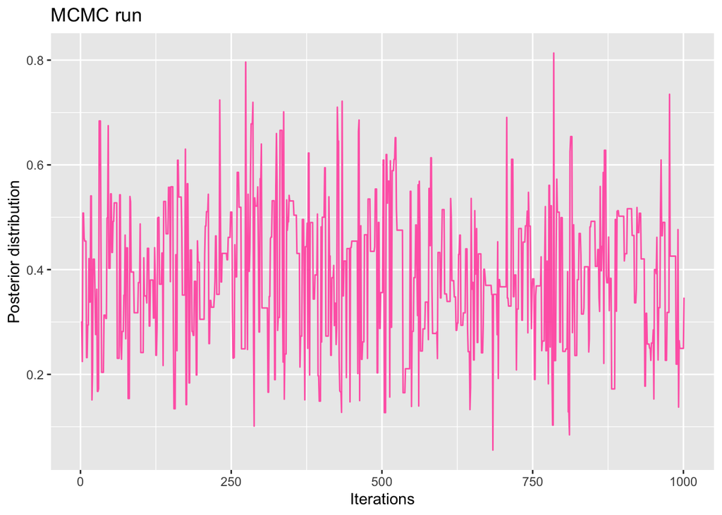

```r
mcmc <- data.frame(iterations=seq(1,iter+1,1),chain)

# Plot
ggplot(mcmc, aes(x=iterations, y=chain)) +
  geom_line(color="hotpink")+
  labs(title="MCMC run",x="Iterations", y="Posterior distribution")
```

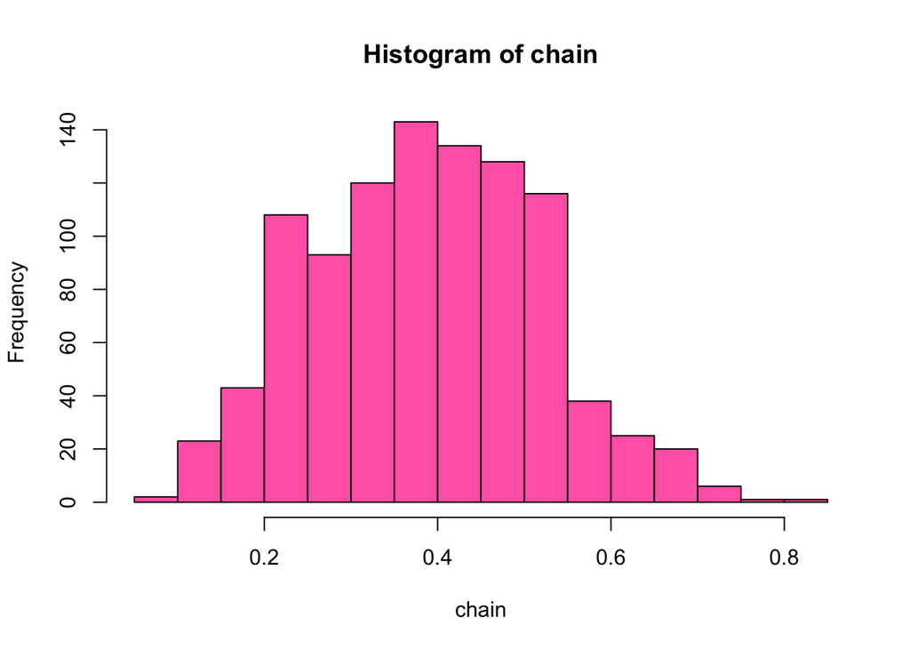

```r
hist(chain,col="hotpink")
```

```r
acceptance = 1-mean(duplicated(chain)) # La proporción de los theta que si fueron aceptados, lo hicimos bien o no?
acceptance
```

```
## [1] 0.4235764
```

Un MCMC lo debemos correr un minimo de dos veces para asegurarnos de que el milpies se ve dos veces igual, esto nos asegura si estamos convergiendo al mismo máximo.

## Ejercicio extra: Cambiando la propuesta

Las propuestas para encontrar nuevos valores del parámetro $\theta_new$ pueden ser buenas o malas. Como en cualquier experimento de laboratorio, cambiar estas propuestas, o agregar nuevas es necesario para poder mejorar el MCMC.

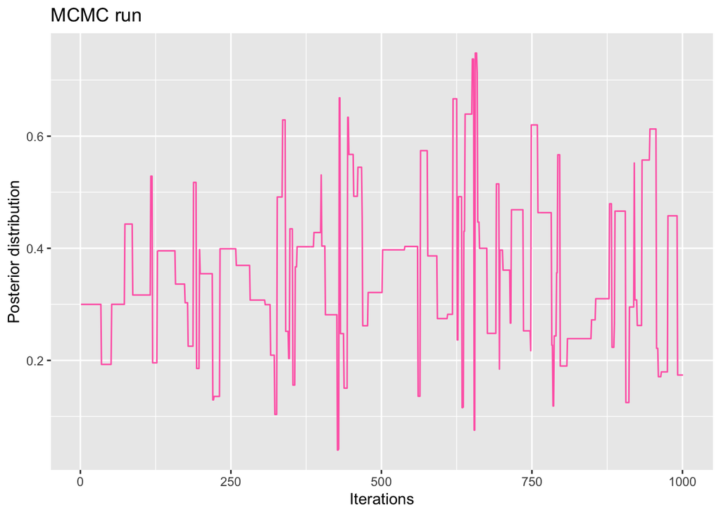

```r
## Una nueva propuesta bajo una distribución beta que se ve como U
proposalfunction2 <- function(nvals=1){
  beta_val<-rbeta(nvals,shape1=0.1 ,shape2=0.1) #
  return(beta_val)}

a<-2
b<-5

run_metropolis_MCMC2 <- function(startvalue, iterations){
    chain = rep (0,iterations+1)
    chain[1] = startvalue # Valor inicial del parametro
    for (i in 1:iterations){
        theta_old<-chain[i]
        theta_new = proposalfunction2(1) # Nueva propuesta de una beta

        odds = (binomial_likelihood(theta_new,observed_dates,n=3)*prior_distribution(theta_new, a,b))/(binomial_likelihood(theta_old,observed_dates,n=3)*prior_distribution(theta_old, a,b))

        if (runif(1) < odds){  # La parte de la aceptación
            chain[i+1] = theta_new
        }else{ # La parte del rechazo
            chain[i+1] = theta_old
        }
    }
    return(chain)
}

startvalue = 0.3 # Valor inicial
iter=1000
chain = run_metropolis_MCMC2(startvalue, iter) # Do 10,000 steps

mcmc <- data.frame(iterations=seq(1,iter+1,1),chain)

# Plot
ggplot(mcmc, aes(x=iterations, y=chain)) +
  geom_line(color="hotpink")+
  labs(title="MCMC run",x="Iterations", y="Posterior distribution")
```

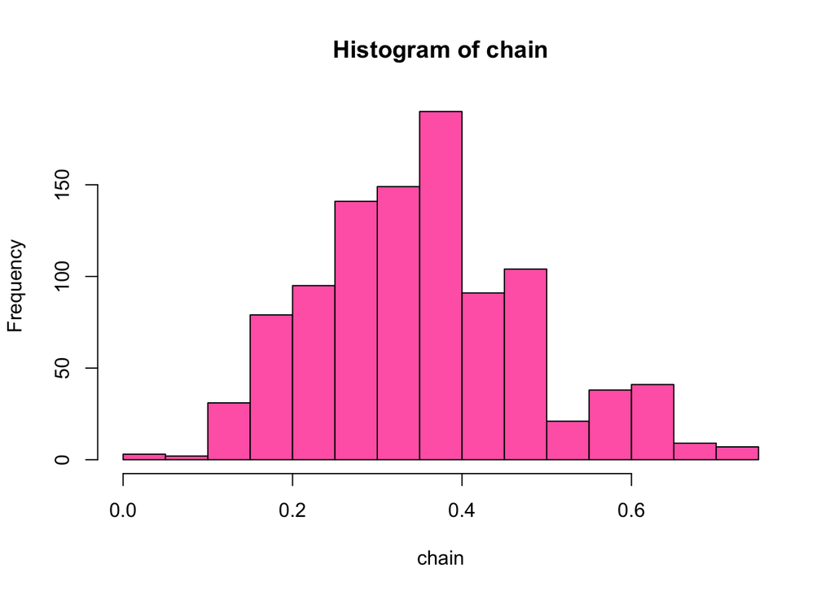

```r
hist(chain,col="hotpink")
```

```r
acceptance = 1-mean(duplicated(chain)) # Proporción de aceptación. Cómo lo hicimos_
acceptance
```

```
## [1] 0.1018981
```

## Referencias

Muchas de estas ideas y código proviene de los siguientes recursos

1. Doing Bayesian Data Analysis in brms and the tidyverse by A Solomon Kurz https://bookdown.org/ajkurz/DBDA_recoded/
2. Dating for Bayesians: Here’s How To Use Statistics To Improve Your Love Life by Andy Kiersz https://www.businessinsider.com/dating-for-bayesians-heres-how-to-use-statistics-to-improve-your-love-life-2013-11